# Lab7

Suhwan Bong

2023-10-24

We will follow a source code of `Doing Data Science in R: An Introduction for Social Scientists` made by Mark Andrews in generalized linear model section. Also, we will follow the chapter 5.3 of `Introduction to Statistical Learning` for the cross-validation section.

## 1. Generalized linear model

```r
library(tidyverse)
```

```r
library(cowplot)
library(latex2exp)
library(brms)
library(broom)
library(MASS)
```

### 1-1. Model description

Generalized linear models are regression models that extend the normal linear model so that it can model data that is not normally distributed around a mean that is a linear function of predictors. Generalized linear model can be defined as:
$$y_i \sim D(\theta_i, \psi),\quad f(\theta_i) = \beta_0 + \sum_{k=1}^K
\beta_k x_{ki},\quad\text{for $i \in 1\ldots n$},$$
where $D(\theta_i, \psi)$ is some probability distribution centered at $\theta_i$ and with an optional parameter $\psi$ that controls the scale or shape of the distribution, and where $f$ is a monotonic (and thus invertible) *link* function.

For example, the binary logistic regression model is defined exactly as follows.
$$y_i \sim \textrm{Bernoulli}(\theta_i),\quad
\textrm{logit}\left(\theta_i\right) = \beta_0 + \sum_{k=1}^K \beta_k
x_{ki},\quad\text{for $i \in 1 \ldots n$}.$$
Thus, in this case, $D(\theta_i, \psi)$ is $\textrm{Bernoulli}(\theta_i)$, there so there is no optional $\psi$ parameter, and the link function is the $\textrm{logit}$ function.

### 1-2. Logistic Regression

```r
affairs_df <- read_csv('affairs.csv')
```

It has 601 observations for 9 variables. One of these 9 variables is `affairs`, which gives the number of times the respondent to the survey engaged in an extramarital act of sexual intercourse in the past year. The distribution of values of the `affairs` variable are as follows.

```r
affairs_df %>%
  pull(affairs) %>%
  table()
```

```
## .
##   0   1   2   3   7  12
## 451  34  17  19  42  38
```

Here, the values of 0, 1, 2, and 3 indicate exactly 0, 1, 2, and 3 times, while 7 indicates 4-10 times, and 12 indicates monthly or weekly or daily. To simplify matters, we will create a new variable `cheater` that takes the value of `TRUE` if the respondent engaged in any amount of extramarital sexual intercourse, and `FALSE` otherwise.

```r
library(magrittr)
```

```r
affairs_df %<>% mutate(cheater = affairs > 0)
```

This variable, which is obviously binary, will be our outcome variable. Other variables, which can serve as explanatory variables, include `gender` and `rating`. The `rating` variable has values of 1 to 5 that mean the following: 1 = very unhappy, 2 = somewhat unhappy, 3 = average, 4 = happier than average, 5 = very happy.

Using R, we can implement a binary logistic regression using the `glm` function. The `glm` function is used almost identically to how we used `lm`, but because it is for different types of generalized linear models and not just the binary logistic regression model, we must specify both the outcome variable probability distribution that we assume and also the link function.

```r
affairs_m <- glm(cheater ~ gender + rating,
                 family = binomial(link = 'logit'),
                 data = affairs_df)

summary(affairs_m)
```

```
##
## Call:
## glm(formula = cheater ~ gender + rating, family = binomial(link = "logit"),
##     data = affairs_df)
##
## Coefficients:
##             Estimate Std. Error z value Pr(>|z|)
## (Intercept)  0.70933    0.33745   2.102   0.0356 *
## gendermale   0.25474    0.19541   1.304   0.1924
## rating      -0.51083    0.08495  -6.013 1.82e-09 ***
## ---
## Signif. codes:  0 '***' 0.001 '**' 0.01 '*' 0.05 '.' 0.1 ' ' 1
##
## (Dispersion parameter for binomial family taken to be 1)
##
##     Null deviance: 675.38  on 600  degrees of freedom
## Residual deviance: 636.58  on 598  degrees of freedom
## AIC: 642.58
##
## Number of Fisher Scoring iterations: 4
```

You should look carefully at the model deviance for model selection.

Just like with `lm`, we may see the maximum likelihood estimates of $\beta_0, \beta_1, \beta_2$ with the `coef()` function.

```r
(estimates <- coef(affairs_m))
```

```
## (Intercept)  gendermale      rating
##   0.7093252   0.2547430  -0.5108324
```

For hypothesis testing and constructing confidence intervals for these coefficients:

```r
library(modelr)
```

```r
X <- model_matrix(affairs_df, cheater ~ gender + rating) %>%
  as.matrix()

p <- affairs_m$fitted.values
S <- diag(p * (1 - p))

(std_err <- solve(t(X) %*% S %*% X) %>% diag() %>% sqrt())
```

```
## (Intercept)  gendermale      rating
##  0.33745388  0.19540750  0.08495009
```

In the table above, the `z value` is the test statistics for the null hypothesis tests that the true values of each $\beta_k$ are zero. In other words, it is $\hat{\beta}_k/\hat{\textrm{se}}_k$, as can be easily verified. The accompanying p-value, listed as `Pr(>|z|)`, is the probability of getting a result more extreme than the test statistic in a standard normal distribution.

```r
z <- summary(affairs_m)$coefficients[,'z value']
2 * pnorm(abs(z), lower.tail = F)
```

```
##  (Intercept)   gendermale       rating
## 3.555402e-02 1.923529e-01 1.817574e-09
```

The confidence intervals for the coefficients can be obtained as follows.

```r
confint.default(affairs_m)
```

```
##                   2.5 %     97.5 %
## (Intercept)  0.04792776  1.3707227
## gendermale  -0.12824866  0.6377347
## rating      -0.67733153 -0.3443333
```

We can confirm that for each coefficient $\beta_k$, this is $\hat{\beta}_k \pm \hat{\textrm{se}}_k \cdot \zeta_{(0.975)}$, where $\zeta_{(0.975)}$ is the value below which lies $97.5$% of the probability mass in a standard normal distribution. For example, for the case of `gender`, we have

```r
estimates['gendermale'] + c(-1, 1) * std_err['gendermale'] * qnorm(0.975)
```

```
## [1] -0.1282487  0.6377347
```

```r
estimates_log = estimates
```

### 1-3. Poisson Regression

Possion Regression is another possible kind of generalized linear model.

$$y_i \sim \textrm{Poisson}(\lambda_i),\quad \lambda_i = e^{\phi_i},\quad
\phi_i = \beta_0 + \sum_{k=1}^K \beta_k x_{ki},\quad\text{for $i \in 1
\ldots n$}.$$

As an example of a problem seemingly suited to a Poisson regression model, we will use the following data set.

```r
lbw_df <- read_csv('lbw.csv')
```

```
## ──────────────────────────────────────────────────────── Delimiter: "," dbl
## (11): ...1, low, smoke, race, age, lwt, ptl, ht, ui, ftv, bwt
```

```r
lbw_df
```

```
## # A tibble: 189 × 11
##     ...1   low smoke  race   age   lwt   ptl    ht    ui   ftv   bwt
##    <dbl> <dbl> <dbl> <dbl> <dbl> <dbl> <dbl> <dbl> <dbl> <dbl> <dbl>
##  1     1     0     0     2    19   182     0     0     1     0  2523
##  2     2     0     0     3    33   155     0     0     0     3  2551
##  3     3     0     1     1    20   105     0     0     0     1  2557
##  4     4     0     1     1    21   108     0     0     1     2  2594
##  5     5     0     1     1    18   107     0     0     1     0  2600
##  6     6     0     0     3    21   124     0     0     0     0  2622
##  7     7     0     0     1    22   118     0     0     0     1  2637
##  8     8     0     0     3    17   103     0     0     0     1  2637
##  9     9     0     1     1    29   123     0     0     0     1  2663
## 10    10     0     1     1    26   113     0     0     0     0  2665
## # ℹ 179 more rows
```

This gives us data relating to low birth weight infants. One variable in this data set is `ftv`, which is the number of visits to the doctor by the mother in her trimester of pregnancy.

[output not shown]

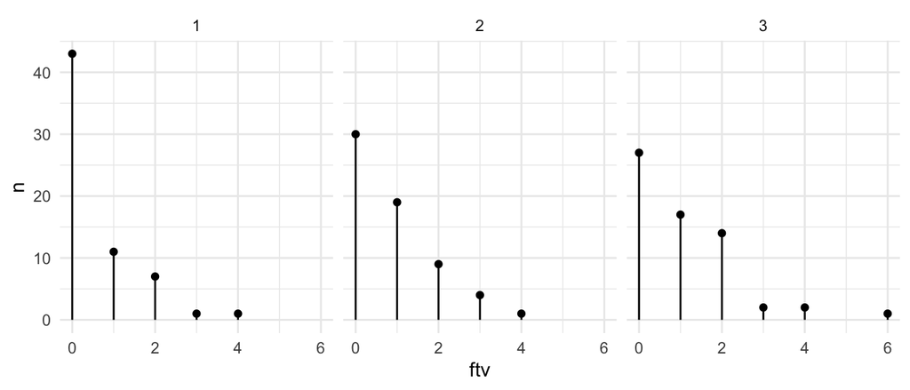

The number of visits to a doctor in the first trimester of pregnancy for each age tercile.

```r
lbw_df %>%
  mutate(age_grp = ntile(age, 3)) %>%
  group_by(ftv, age_grp) %>%
  summarise(n = n()) %>%
  ggplot(aes(x = ftv, y = n)) +
  geom_point() +
  geom_segment(aes(x = ftv, xend = ftv, y = 0, yend = n)) +
  facet_grid(~age_grp) +
  theme_minimal()
```

In general, in Poisson regression, we model a count response variable as a Poisson distribution whose parameter $\lambda$ varies by a set of explanatory variables. More precisely, we model the log of $\lambda$ as a linear function of the explanatory variables.

Here, we will use the `lbw_df` data set and model `ftv` as a function of the mother’s age.

```r
lbw_m <- glm(ftv ~ age,
             data = lbw_df,
             family = poisson(link = 'log')
)

summary(lbw_m)
```

```
##
## Call:
## glm(formula = ftv ~ age, family = poisson(link = "log"), data = lbw_df)
##
## Coefficients:
##             Estimate Std. Error z value Pr(>|z|)
## (Intercept) -1.41277    0.35717  -3.955 7.64e-05 ***
## age          0.04929    0.01405   3.509 0.000449 ***
## ---
## Signif. codes:  0 '***' 0.001 '**' 0.01 '*' 0.05 '.' 0.1 ' ' 1
##
## (Dispersion parameter for poisson family taken to be 1)
##
##     Null deviance: 264.52  on 188  degrees of freedom
## Residual deviance: 252.96  on 187  degrees of freedom
## AIC: 467.03
##
## Number of Fisher Scoring iterations: 6
```

Note that we use `glm` just we did with logistic regression, but use `family = poisson(link = 'log')`. It would have been sufficient to use `family = poisson()`, given the `link = 'log'` is the default.

First, let us look at $\hat{\beta}$, the maximum likelihood estimators for $\vec{\beta}$, which we can do with `coef`.

```r
(estimates <- coef(lbw_m))
```

```
## (Intercept)         age
## -1.41276618  0.04929373
```

Now, let us turn to hypothesis tests and confidence intervals. We can begin by examining the coefficients table.

```r
summary(lbw_m)$coefficients
```

```
##                Estimate Std. Error   z value     Pr(>|z|)
## (Intercept) -1.41276618 0.35717007 -3.955444 7.639269e-05
## age          0.04929373 0.01404709  3.509178 4.494944e-04
```

```r
library(modelr)
X <- model_matrix(lbw_df, ~ age) %>%
  as.matrix()
W <- diag(lbw_m$fitted.values)

std_err <- solve(t(X) %*% W %*% X) %>% diag() %>% sqrt()
std_err
```

```
## (Intercept)         age
##  0.35717008  0.01404709
```

The `z value` is the statistic for the hypothesis that each $\hat{\beta}_k$ is zero, which is easily verified as the maximum likelihood estimate divided by its corresponding standard error.

```r
(z_stat <- estimates / std_err)
```

```
## (Intercept)         age
##   -3.955444    3.509178
```

The corresponding p-values are given by `Pr(>|z|)`, which is also easily verified as the probability of getting a value as or more extreme than `z value` in a standard normal distribution, as we see in the following.

```r
2 * pnorm(abs(z_stat), lower.tail = F)
```

```
##  (Intercept)          age
## 7.639269e-05 4.494944e-04
```

The 95% confidence interval for `age` is as follows.

```r
confint.default(lbw_m, parm='age')
```

```
##          2.5 %     97.5 %
## age 0.02176194 0.07682551
```

We can confirm that this is $\hat{\beta}_k \pm \hat{\textrm{se}}_k \cdot \zeta_{(0.975)}$.

```r
estimates['age'] + c(-1, 1) * std_err['age'] * qnorm(0.975)
```

```
## [1] 0.02176194 0.07682551
```

```r
estimates_poi = estimates
```

### 1-4. Zero-inflated Poisson Regression

```r
library(pscl)
head(bioChemists)
```

```
##   art   fem     mar kid5  phd ment
## 1   0   Men Married    0 2.52    7
## 2   0 Women  Single    0 2.05    6
## 3   0 Women  Single    0 3.75    6
## 4   0   Men Married    1 1.18    3
## 5   0 Women  Single    0 3.75   26
## 6   0 Women Married    2 3.59    2
```

We will use a simple model,
$$\log(\lambda_i) = \beta_0 + \beta_1 \cdot x_1$$

The variance of a sample is greater than would be expected according to a given theoretical model, then we say the data is overdispersed. Especially, in count data, if the variance of a sample is much greater than its mean, we say it is overdispersed.

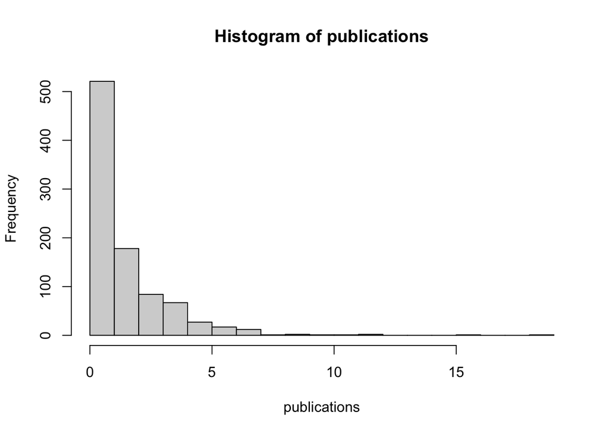

```r
publications <- bioChemists$art
hist(publications, breaks = 20)
```

```r
mean(publications)
```

```
## [1] 1.692896
```

```r
var(publications)
```

```
## [1] 3.709742
```

Variance of the data is a lot greater than its mean.

```r
poi.mod <- glm(art ~ fem,
             data = bioChemists,
             family = poisson(link = 'log'))
summary(poi.mod)
```

```
##
## Call:
## glm(formula = art ~ fem, family = poisson(link = "log"), data = bioChemists)
##
## Coefficients:
##             Estimate Std. Error z value Pr(>|z|)
## (Intercept)  0.63265    0.03279  19.293  < 2e-16 ***
## femWomen    -0.24718    0.05187  -4.765 1.89e-06 ***
## ---
## Signif. codes:  0 '***' 0.001 '**' 0.01 '*' 0.05 '.' 0.1 ' ' 1
##
## (Dispersion parameter for poisson family taken to be 1)
##
##     Null deviance: 1817.4  on 914  degrees of freedom
## Residual deviance: 1794.4  on 913  degrees of freedom
## AIC: 3466.1
##
## Number of Fisher Scoring iterations: 5
```

We will use zero-inflated poisson regression. This model can be used when a lot of observations have a value of 0, thus, zero-inflated. We have two parameters, $\pi, \lambda$.
$$\Pr(Y=0) = \pi + (1-\pi)e^{-\lambda}\\
\Pr(Y=y_i) = (1-\pi)\frac{\lambda^{y_i}e^{-\lambda}}{y_i!}, \quad y_i =
1,2,3,\dots$$

If we use one explanatory variable $X$, the model is transformed as
$$\log(\lambda_i) = \alpha_0 + \alpha_1X_i\\
\text{logit}(\pi_i) = \beta_0 + \beta_1X_i.$$

```r
zero.inf.mod <- zeroinfl(
  art ~ fem, data = bioChemists
)
summary(zero.inf.mod)
```

```
##
## Call:
## zeroinfl(formula = art ~ fem, data = bioChemists)
##
## Pearson residuals:
##     Min      1Q  Median      3Q     Max
## -1.1327 -1.0324 -0.3302  0.3719 10.2987
##
## Count model coefficients (poisson with log link):
##             Estimate Std. Error z value Pr(>|z|)
## (Intercept)  0.85443    0.03781  22.600  < 2e-16 ***
## femWomen    -0.23933    0.06242  -3.834 0.000126 ***
##
## Zero-inflation model coefficients (binomial with logit link):
##             Estimate Std. Error z value Pr(>|z|)
## (Intercept) -1.39315    0.14716  -9.467   <2e-16 ***
## femWomen     0.03885    0.23760   0.164     0.87
## ---
## Signif. codes:  0 '***' 0.001 '**' 0.01 '*' 0.05 '.' 0.1 ' ' 1
##
## Number of iterations in BFGS optimization: 16
## Log-likelihood: -1670 on 4 Df
```

```r
AIC(poi.mod, zero.inf.mod)
```

```
##              df      AIC
## poi.mod       2 3466.118
## zero.inf.mod  4 3348.480
```

### 1-5. Negative Binomial Regression

Negative binomial regression is an alternative to Poisson regression that can be used with overdispersed count data. A negative binomial distribution is a distribution over non-negative integers. The probability mass function for the negative binomial distribution is:
$$\Pr(X = k \vert r, \theta) = {r+k-1 \choose k} \theta^r (1-\theta)^k.$$

In negative binomial regression, we have observed counts $y_1, y_2, \dots, y_n$ and some predictor variables $x_1, x_2, \dots, x_n$ and we assume that
$$y_i \sim \text{NegBin}(\mu_i, r)$$
where $\text{NegBin}(\mu, r)$ is a negative binomial with mean $\mu_i$ and a dispersion parameter $r$, and then
$$\log(\mu_i) = \beta_0 + \beta_1 x_i$$

For example,

```r
nb_mod <- glm.nb(art ~ fem, data = bioChemists)
tidy(nb_mod)
```

```
## # A tibble: 2 × 5
##   term        estimate std.error statistic  p.value
##   <chr>          <dbl>     <dbl>     <dbl>    <dbl>
## 1 (Intercept)    0.633    0.0472     13.4  5.10e-41
## 2 femWomen      -0.247    0.0720     -3.43 6.01e- 4
```

### 1-6. Prediction

Given models, we can easily make predictions based on any given values of our predictors.

For example, the predicted log odds of having an affair for a male with a `rating` value of 4 is as follows:

```r
predicted_logodds <-
  (estimates_log['(Intercept)'] + estimates_log['gendermale'] * 1 + estimates_log['rating'] * 4) %>%
  unname()
predicted_logodds
```

```
## [1] -1.079261
```

If we then want the predicted probability, we use the inverse logit function. While this function does exist in R as the `plogis` function, it is nonetheless instructive to implement ourselves as it is a very simple function.

```r
ilogit <- function(phi){
  1/(1 + exp(-phi))
}
```

Using this function, the predicted probability is as follows:

```r
ilogit(predicted_logodds)
```

```
## [1] 0.2536458
```

Also, for poisson regression, the predicted log of the rate for mothers aged 20, 25, 30 is easily calculated as follows.

```r
estimates_poi['(Intercept)'] + estimates_poi['age'] * c(20, 25, 30)
```

```
## [1] -0.42689167 -0.18042304  0.06604559
```

And so the predicted rate for these women is as follows

```r
exp(estimates_poi['(Intercept)'] + estimates_poi['age'] * c(20, 25, 30))
```

```
## [1] 0.6525342 0.8349169 1.0682754
```

## 2. Cross-validation

In this lab, we explore the resampling techniques. Some of the commands in this lab may take a while to run on your computer.

### 2-1. The Validation Set Approach

We explore the use of the validation set approach in order to estimate the test error rates that result from fitting various linear models on the `Auto` data set.

Before we begin, we use the `set.seed()` function in order to set a for `R`’s random number generator, so that the reader of this book will obtain precisely the same results as those shown below. It is generally a good idea to set a random seed when performing an analysis such as cross-validation that contains an element of randomness, so that the results obtained can be reproduced precisely at a later time.

We begin by using the `sample()` function to split the set of observations into two halves, by selecting a random subset of $196$ observations out of the original $392$ observations. We refer to these observations as the training set.

```r
library(ISLR2)
set.seed(1)
train <- sample(392, 196)
```

(Here we use a shortcut in the sample command; see `?sample` for details.) We then use the `subset` option in `lm()` to fit a linear regression using only the observations corresponding to the training set.

```r
lm.fit <- lm(mpg ~ horsepower, data = Auto, subset = train)
```

We now use the `predict()` function to estimate the response for all $392$ observations, and we use the `mean()` function to calculate the MSE of the $196$ observations in the validation set. Note that the `-train` index below selects only the observations that are not in the training set.

```r
attach(Auto)
mean((mpg - predict(lm.fit, Auto))[-train]^2)
```

```
## [1] 23.26601
```

Therefore, the estimated test MSE for the linear regression fit is $23.27$. We can use the `poly()` function to estimate the test error for the quadratic and cubic regressions.

```r
lm.fit2 <- lm(mpg ~ poly(horsepower, 2), data = Auto,
    subset = train)
mean((mpg - predict(lm.fit2, Auto))[-train]^2)
```

```
## [1] 18.71646
```

```r
lm.fit3 <- lm(mpg ~ poly(horsepower, 3), data = Auto,
    subset = train)
mean((mpg - predict(lm.fit3, Auto))[-train]^2)
```

```
## [1] 18.79401
```

These error rates are $18.72$ and $18.79$, respectively. If we choose a different training set instead, then we will obtain somewhat different errors on the validation set.

```r
set.seed(2)
train <- sample(392, 196)
lm.fit <- lm(mpg ~ horsepower, subset = train)
mean((mpg - predict(lm.fit, Auto))[-train]^2)
```

```
## [1] 25.72651
```

```r
lm.fit2 <- lm(mpg ~ poly(horsepower, 2), data = Auto,
    subset = train)
mean((mpg - predict(lm.fit2, Auto))[-train]^2)
```

```
## [1] 20.43036
```

```r
lm.fit3 <- lm(mpg ~ poly(horsepower, 3), data = Auto,
    subset = train)
mean((mpg - predict(lm.fit3, Auto))[-train]^2)
```

```
## [1] 20.38533
```

Using this split of the observations into a training set and a validation set, we find that the validation set error rates for the models with linear, quadratic, and cubic terms are $25.73$, $20.43$, and $20.39$, respectively.

These results are consistent with our previous findings: a model that predicts `mpg` using a quadratic function of `horsepower` performs better than a model that involves only a linear function of `horsepower`, and there is little evidence in favor of a model that uses a cubic function of `horsepower`.

### 2-2. Leave-One-Out Cross-Validation

The LOOCV estimate can be automatically computed for any generalized linear model using the `glm()` and `cv.glm()` functions. We used the `glm()` function to perform logistic regression by passing in the `family = "binomial"` argument. But if we use `glm()` to fit a model without passing in the `family` argument, then it performs linear regression, just like the `lm()` function. So for instance,

```r
glm.fit <- glm(mpg ~ horsepower, data = Auto)
coef(glm.fit)
```

```
## (Intercept)  horsepower
##  39.9358610  -0.1578447
```

and

```r
lm.fit <- lm(mpg ~ horsepower, data = Auto)
coef(lm.fit)
```

```
## (Intercept)  horsepower
##  39.9358610  -0.1578447
```

yield identical linear regression models. In this lab, we will perform linear regression using the `glm()` function rather than the `lm()` function because the former can be used together with `cv.glm()`. The `cv.glm()` function is part of the `boot` library.

```r
library(boot)
glm.fit <- glm(mpg ~ horsepower, data = Auto)
cv.err <- cv.glm(Auto, glm.fit)
cv.err$delta
```

```
## [1] 24.23151 24.23114
```

The `cv.glm()` function produces a list with several components. The two numbers in the `delta` vector contain the cross-validation results. In this case the numbers are identical (up to two decimal places) and correspond to the LOOCV statistic. Below, we discuss a situation in which the two numbers differ. Our cross-validation estimate for the test error is approximately $24.23$.

We can repeat this procedure for increasingly complex polynomial fits. To automate the process, we use the `for()` function to initiate a which iteratively fits polynomial regressions for polynomials of order $i=1$ to $i=10$, computes the associated cross-validation error, and stores it in the $i$th element of the vector `cv.error`. We begin by initializing the vector.

```r
cv.error <- rep(0, 10)
for (i in 1:10) {
  glm.fit <- glm(mpg ~ poly(horsepower, i), data = Auto)
  cv.error[i] <- cv.glm(Auto, glm.fit)$delta[1]
}
cv.error
```

```
##  [1] 24.23151 19.24821 19.33498 19.42443 19.03321 18.97864 18.83305 18.96115
##  [9] 19.06863 19.49093
```

We see a sharp drop in the estimated test MSE between the linear and quadratic fits, but then no clear improvement from using higher-order polynomials.

### 2-3. $k$-Fold Cross-Validation

The `cv.glm()` function can also be used to implement $k$-fold CV. Below we use $k=10$, a common choice for $k$, on the `Auto` data set. We once again set a random seed and initialize a vector in which we will store the CV errors corresponding to the polynomial fits of orders one to ten.

```r
set.seed(17)
cv.error.10 <- rep(0, 10)
for (i in 1:10) {
  glm.fit <- glm(mpg ~ poly(horsepower, i), data = Auto)
  cv.error.10[i] <- cv.glm(Auto, glm.fit, K = 10)$delta[1]
}
cv.error.10
```

```
##  [1] 24.27207 19.26909 19.34805 19.29496 19.03198 18.89781 19.12061 19.14666
##  [9] 18.87013 20.95520
```

Notice that the computation time is shorter than that of LOOCV. We still see little evidence that using cubic or higher-order polynomial terms leads to lower test error than simply using a quadratic fit.

### 2-4. Bootstrap

We illustrate the use of the bootstrap, as well as on an example involving estimating the accuracy of the linear regression model on the `Auto` data set.

#### Estimating the Accuracy of a Statistic of Interest

One of the great advantages of the bootstrap approach is that it can be applied in almost all situations. No complicated mathematical calculations are required. Performing a bootstrap analysis in `R` entails only two steps. First, we must create a function that computes the statistic of interest. Second, we use the `boot()` function, which is part of the `boot` library, to perform the bootstrap by repeatedly sampling observations from the data set with replacement.

The `Portfolio` data set in the `ISLR2` package is simulated data of $100$ pairs of returns. To illustrate the use of the bootstrap on this data, we must first create a function, `alpha.fn()`, which takes as input the $(X,Y)$ data as well as a vector indicating which observations should be used to estimate $\alpha$. The function then outputs the estimate for $\alpha$ based on the selected observations.

```r
alpha.fn <- function(data, index) {
  X <- data$X[index]
  Y <- data$Y[index]
  (var(Y) - cov(X, Y)) / (var(X) + var(Y) - 2 * cov(X, Y))
}
```

```r
alpha.fn(Portfolio, 1:100)
```

```
## [1] 0.5758321
```

The next command uses the `sample()` function to randomly select $100$ observations from the range $1$ to $100$, with replacement. This is equivalent to constructing a new bootstrap data set and recomputing $\hat{\alpha}$ based on the new data set.

```r
set.seed(7)
alpha.fn(Portfolio, sample(100, 100, replace = T))
```

```
## [1] 0.5385326
```

We can implement a bootstrap analysis by performing this command many times, recording all of the corresponding estimates for $\alpha$, and computing the resulting standard deviation. However, the `boot()` function automates this approach. Below we produce $R=1,000$ bootstrap estimates for $\alpha$.

```r
boot(Portfolio, alpha.fn, R = 1000)
```

```
##
## ORDINARY NONPARAMETRIC BOOTSTRAP
##
##
## Call:
## boot(data = Portfolio, statistic = alpha.fn, R = 1000)
##
##
## Bootstrap Statistics :
##      original       bias    std. error
## t1* 0.5758321 0.0007959475  0.08969074
```

The final output shows that using the original data, $\hat{\alpha}=0.5758$, and that the bootstrap estimate for ${\rm SE}(\hat{\alpha})$ is $0.0897$.

#### Estimating the Accuracy of a Linear Regression Model

The bootstrap approach can be used to assess the variability of the coefficient estimates and predictions from a statistical learning method. Here we use the bootstrap approach in order to assess the variability of the estimates for $\beta_0$ and $\beta_1$, the intercept and slope terms for the linear regression model that uses `horsepower` to predict `mpg` in the `Auto` data set. We will compare the estimates obtained using the bootstrap to those obtained using the formulas for ${\rm SE}(\hat{\beta}_0)$ and ${\rm SE}(\hat{\beta}_1)$.

We first create a simple function, `boot.fn()`, which takes in the `Auto` data set as well as a set of indices for the observations, and returns the intercept and slope estimates for the linear regression model. We then apply this function to the full set of $392$ observations in order to compute the estimates of $\beta_0$ and $\beta_1$ on the entire data set using the usual linear regression coefficient estimate formulas.

```r
boot.fn <- function(data, index)
  coef(lm(mpg ~ horsepower, data = data, subset = index))
boot.fn(Auto, 1:392)
```

```
## (Intercept)  horsepower
##  39.9358610  -0.1578447
```

The `boot.fn()` function can also be used in order to create bootstrap estimates for the intercept and slope terms by randomly sampling from among the observations with replacement. Here we give two examples.

```r
set.seed(1)
boot.fn(Auto, sample(392, 392, replace = T))
```

```
## (Intercept)  horsepower
##  40.3404517  -0.1634868
```

```r
boot.fn(Auto, sample(392, 392, replace = T))
```

```
## (Intercept)  horsepower
##  40.1186906  -0.1577063
```

Next, we use the `boot()` function to compute the standard errors of 1,000 bootstrap estimates for the intercept and slope terms.

```r
boot(Auto, boot.fn, 1000)
```

```
##
## ORDINARY NONPARAMETRIC BOOTSTRAP
##
##
## Call:
## boot(data = Auto, statistic = boot.fn, R = 1000)
##
##
## Bootstrap Statistics :
##       original        bias    std. error
## t1* 39.9358610  0.0544513229 0.841289790
## t2* -0.1578447 -0.0006170901 0.007343073
```

This indicates that the bootstrap estimate for ${\rm SE}(\hat{\beta}_0)$ is $0.84$, and that the bootstrap estimate for ${\rm SE}(\hat{\beta}_1)$ is $0.0073$. Standard formulas can be used to compute the standard errors for the regression coefficients in a linear model. These can be obtained using the `summary()` function.

```r
summary(lm(mpg ~ horsepower, data = Auto))$coef
```

```
##               Estimate  Std. Error   t value      Pr(>|t|)
## (Intercept) 39.9358610 0.717498656  55.65984 1.220362e-187
## horsepower  -0.1578447 0.006445501 -24.48914  7.031989e-81
```

The standard error estimates for $\hat{\beta}_0$ and $\hat{\beta}_1$ obtained using the general formulas are $0.717$ for the intercept and $0.0064$ for the slope. Interestingly, these are somewhat different from the estimates obtained using the bootstrap. Does this indicate a problem with the bootstrap? In fact, it suggests the opposite. Recall that the standard formulas rely on certain assumptions. For example, they depend on the unknown parameter $\sigma^2$, the noise variance. We then estimate $\sigma^2$ using the RSS. Now although the formulas for the standard errors do not rely on the linear model being correct, the estimate for $\sigma^2$ does.

In fact, there is a non-linear relationship in the data, and so the residuals from a linear fit will be inflated, and so will $\hat{\sigma}^2$. Secondly, the standard formulas assume (somewhat unrealistically) that the $x_i$ are fixed, and all the variability comes from the variation in the errors $\epsilon_i$. The bootstrap approach does not rely on any of these assumptions, and so it is likely giving a more accurate estimate of the standard errors of $\hat{\beta}_0$ and $\hat{\beta}_1$ than is the `summary()` function.

Below we compute the bootstrap standard error estimates and the standard linear regression estimates that result from fitting the quadratic model to the data. Since this model provides a good fit to the data, there is now a better correspondence between the bootstrap estimates and the standard estimates of ${\rm SE}(\hat{\beta}_0)$, ${\rm SE}(\hat{\beta}_1)$ and ${\rm SE}(\hat{\beta}_2)$.

```r
boot.fn <- function(data, index)
  coef(
      lm(mpg ~ horsepower + I(horsepower^2),
        data = data, subset = index)
    )
set.seed(1)
boot(Auto, boot.fn, 1000)
```

```
##
## ORDINARY NONPARAMETRIC BOOTSTRAP
##
##
## Call:
## boot(data = Auto, statistic = boot.fn, R = 1000)
##
##
## Bootstrap Statistics :
##         original        bias     std. error
## t1* 56.900099702  3.511640e-02 2.0300222526
## t2* -0.466189630 -7.080834e-04 0.0324241984
## t3*  0.001230536  2.840324e-06 0.0001172164
```

```r
summary(
    lm(mpg ~ horsepower + I(horsepower^2), data = Auto)
  )$coef
```

```
##                     Estimate   Std. Error   t value      Pr(>|t|)
## (Intercept)     56.900099702 1.8004268063  31.60367 1.740911e-109
## horsepower      -0.466189630 0.0311246171 -14.97816  2.289429e-40
## I(horsepower^2)  0.001230536 0.0001220759  10.08009  2.196340e-21
```

## 3. Exercises

### Exercise 1

1. Using the `affair` data set, select three variables which you think are related to the probability of cheating. Perform a proper regression model and explain the result.
2. Compare the deviance with the model we fitted in class.
3. Consider that there is a new individual with the three variables you chose above. Randomly select each variable and guess his or her probability of cheating.

### Exercise 2

1. Using the `low birth weight infants` data set, select three variables which you think are related to the number of visits to the doctor. Perform a proper regression model and explain the result.
2. Compare the deviance with the model we fitted in class.
3. Consider that there is a new individual with the three variables you chose above. Randomly select each variable and guess her number of visits to the doctor.

### Exercise 3

Perform a forward selection estimating the probability of cheating with your own criterion. State the best model and explain the result.

### Exercise 4

Build your model that estimates the number of visits to the doctor. State the model and explain the result.

### Exercise 5

1. Using the `affair` data set, fit the following five models and compare the result.
- Intercept model
- Model using ‘age’, ‘gender’, ‘education’, ‘yearmarried’, ‘occupation’ variables only
- Model using ‘age’, ‘gender’, ‘education’, ‘yearmarried’, ‘occupation’ variables and their two way interactions
- Model using ‘age’, ‘gender’, ‘education’, ‘yearmarried’, ‘occupation’ variables and their two and three way interactions.
- Full model using ‘age’, ‘gender’, ‘education’, ‘yearmarried’, ‘occupation’ variables and their all interactions.
2. Using the LOOCV, explain which model shows the best performance.

### Exercise 6

1. Using the `low birth weight infants` data set, fit the following five models and compare the result.
- Intercept model
- Model using ‘age’ and ‘lwt’ variables only
- Model using ‘age’ and ‘lwt’ variables and their quadratic terms
- Model using ‘age’ and ‘lwt’ variables and their quadratic/cubic terms
- Model using ‘age’ and ‘lwt’ variables and their interaction.
2. Using the K-fold cross-validation, explain which model shows the best performance.